# An Analysis of Charlottes Potential as an MLB Team Host City

Christian Etherson

2026-08-06

# Introduction

Charlotte, North Carolina is frequently mentioned as a candidate city for MLB expansion, but “frequently mentioned” is not the same as “supported by data.” This analysis treats the question as a feasibility study built on public sources: historical MLB attendance figures, team performance records, and market demographics. The goal is to answer three practical questions a franchise owner would actually ask:

1. Given Charlotte’s population and income, how many fans could a Charlotte team realistically draw, and how much does team performance move that number?
2. What ticket price is consistent with markets of Charlotte’s size?
3. Do the resulting revenue and payroll figures fall within the range of what other MLB franchises operate on?

Each section builds a regression model, checks whether the model is statistically defensible, and then uses it to generate a prediction for Charlotte.

# 1. Loading Packages and Data

```r
library(Lahman)
library(readxl)
library(dplyr)
library(ggplot2)
```

Two data sources are combined for this analysis: a compiled dataset containing season attendance alongside market variables (population, median household income, presence of NBA/NFL competition, and team payroll) and the Lahman package which supplies MLB team statistics (wins, losses, home runs, shutouts, division results).

```r
attendance_data <- read_excel("BaseballAttendanceData.xlsx")
lahman_teams <- Teams
```

# 2. Data Cleaning

```r
# Drop rows with missing values and coerce win percentage to numeric

attendance_data <- na.omit(attendance_data)
attendance_data$win_pct <- as.numeric(attendance_data$win_pct)

# Restrict Lahman's team records to the 2000-2019 window to match the
# attendance dataset's coverage, and keep only the columns needed for
# this analysis.
lahman_subset <- lahman_teams %>%
  filter(yearID >= 2000 & yearID <= 2019) %>%
  select(yearID, franchID, divID, Rank, DivWin, WSWin, HR, SHO)

# Join on year and franchise so each season/team row carries both the
# market data and the on-field performance data.
teams <- left_join(attendance_data, lahman_subset, by = c("yearID", "franchID"))

head(teams)
```

| rank | yearID | franchID | attendance | Wins | Games | HomeGames | win_pct | population | NBAandNFL | MedHouseIncome | teamPayroll | divID | Rank | DivWin | WSWin | HR | SHO |
| --- | --- | --- | --- | --- | --- | --- | --- | --- | --- | --- | --- | --- | --- | --- | --- | --- | --- |
| 1 | 2000 | ANA | 2066982 | 82 | 162 | 81 | 0.5061728 | 11798000 | 3 | 42045 | 51464167 | W | 3 | N | N | 236 | 3 |
| 2 | 2001 | ANA | 2000919 | 75 | 162 | 81 | 0.4629630 | 11834000 | 3 | 41573 | 46568180 | W | 3 | N | N | 158 | 1 |
| 3 | 2002 | ANA | 2305547 | 99 | 162 | 81 | 0.6111111 | 11870000 | 3 | 41506 | 61721667 | W | 2 | N | Y | 152 | 14 |
| 4 | 2003 | ANA | 3061094 | 77 | 162 | 82 | 0.4753086 | 11906000 | 3 | 41544 | 79031667 | W | 3 | N | N | 150 | 9 |
| 5 | 2004 | ANA | 3375677 | 92 | 162 | 81 | 0.5679012 | 11942000 | 3 | 43518 | 101084667 | W | 1 | Y | N | 162 | 11 |
| 6 | 2005 | ANA | 3404686 | 95 | 162 | 81 | 0.5864198 | 11978000 | 3 | 48166 | 95017822 | W | 1 | Y | N | 147 | 11 |

# 3. Modeling Season Attendance

## 3.1 Building the initial model

The first model treats season attendance as a function of everything that could plausibly drive it: market size (population, median household income), competition for entertainment dollars (whether the metro area also hosts an NBA or NFL team), team quality (win percentage, final division rank, whether the team won the World Series), and how exciting the team was to watch (home runs, shutouts). Team payroll is included as a proxy for a front office’s investment in the roster, which can influence both quality and fan expectations independent of the win/loss record.

```r
attendance_model <- lm(
  attendance ~ population + NBAandNFL + MedHouseIncome + teamPayroll +
    win_pct + as.factor(Rank) + as.factor(WSWin) + HR + SHO,
  data = teams
)

summary(attendance_model)
```

```
##
## Call:
## lm(formula = attendance ~ population + NBAandNFL + MedHouseIncome +
##     teamPayroll + win_pct + as.factor(Rank) + as.factor(WSWin) +
##     HR + SHO, data = teams)
##
## Residuals:
##      Min       1Q   Median       3Q      Max
## -1353922  -365681   -31233   372250  1282650
##
## Coefficients:
##                     Estimate Std. Error t value Pr(>|t|)
## (Intercept)        8.318e+05  3.860e+05   2.155 0.031596 *
## population         1.851e-02  9.234e-03   2.005 0.045439 *
## NBAandNFL         -5.752e+03  4.412e+04  -0.130 0.896319
## MedHouseIncome    -4.411e+00  1.534e+00  -2.875 0.004189 **
## teamPayroll        7.724e-03  5.859e-04  13.184  < 2e-16 ***
## win_pct            3.507e+06  6.910e+05   5.076 5.27e-07 ***
## as.factor(Rank)2  -7.300e+04  7.001e+04  -1.043 0.297513
## as.factor(Rank)3  -1.158e+05  8.453e+04  -1.369 0.171428
## as.factor(Rank)4  -9.524e+04  1.078e+05  -0.884 0.377256
## as.factor(Rank)5  -1.975e+05  1.298e+05  -1.521 0.128840
## as.factor(Rank)6   1.263e+05  1.925e+05   0.656 0.511853
## as.factor(WSWin)Y -8.684e+04  1.178e+05  -0.737 0.461162
## HR                -2.471e+03  6.985e+02  -3.538 0.000437 ***
## SHO               -2.250e+04  6.742e+03  -3.338 0.000902 ***
## ---
## Signif. codes:  0 '***' 0.001 '**' 0.01 '*' 0.05 '.' 0.1 ' ' 1
##
## Residual standard error: 497800 on 558 degrees of freedom
## Multiple R-squared:  0.5019, Adjusted R-squared:  0.4903
## F-statistic: 43.25 on 13 and 558 DF,  p-value: < 2.2e-16
```

## 3.2 Simplifying the model

The initial summary shows that presence of NBA/NFL competition, division rank, and World Series win are not statistically significant predictors once the other variables are accounted for. I removed them using backward elimination: starting from the full model and dropping the non-significant predictors one at a time.

```r
attendance_model <- lm(
  attendance ~ population + MedHouseIncome + teamPayroll + win_pct + HR + SHO,
  data = teams
)

summary(attendance_model)
```

```
##
## Call:
## lm(formula = attendance ~ population + MedHouseIncome + teamPayroll +
##     win_pct + HR + SHO, data = teams)
##
## Residuals:
##      Min       1Q   Median       3Q      Max
## -1350170  -371747   -37637   366870  1303918
##
## Coefficients:
##                  Estimate Std. Error t value Pr(>|t|)
## (Intercept)     4.814e+05  1.725e+05   2.791 0.005437 **
## population      1.821e-02  5.217e-03   3.491 0.000518 ***
## MedHouseIncome -4.349e+00  1.530e+00  -2.842 0.004649 **
## teamPayroll     7.589e-03  5.793e-04  13.100  < 2e-16 ***
## win_pct         4.029e+06  3.886e+05  10.368  < 2e-16 ***
## HR             -2.493e+03  6.953e+02  -3.586 0.000364 ***
## SHO            -2.217e+04  6.690e+03  -3.315 0.000976 ***
## ---
## Signif. codes:  0 '***' 0.001 '**' 0.01 '*' 0.05 '.' 0.1 ' ' 1
##
## Residual standard error: 498100 on 565 degrees of freedom
## Multiple R-squared:  0.4948, Adjusted R-squared:  0.4895
## F-statistic: 92.24 on 6 and 565 DF,  p-value: < 2.2e-16
```

Every remaining variable is statistically significant, and the model’s adjusted R² of roughly 0.49 indicates it explains about half of the season-to-season variation in attendance. The remaining variation is unsurprising since attendance is also shaped by things this dataset doesn’t capture, such as stadium capacity, ticket promotions, weather, and local economic conditions in a given year.

## 3.3 Predicting Charlotte’s attendance

To generate a specific prediction for Charlotte, I plugged in Charlotte’s actual population and median household income and held every other predictor (team payroll, win percentage, home runs, shutouts) at its dataset average. This isolates the effect of market size from the effect of team quality, producing a prediction for what an “average” performing team would draw if it were located in Charlotte.

```r
charlotte_market <- data.frame(
  population = 2367000,
  MedHouseIncome = 84796,
  teamPayroll = mean(teams$teamPayroll),
  win_pct = mean(teams$win_pct),
  HR = mean(teams$HR),
  SHO = mean(teams$SHO)
)

predicted_attendance <- predict(attendance_model, newdata = charlotte_market)
predicted_attendance
```

```
##       1
## 2256422
```

The model predicts an average Charlotte team would draw approximately 2,256,000 fans across a season which is slightly below the league average as shown by the red (Charlotte) and purple (league average) reference lines below.

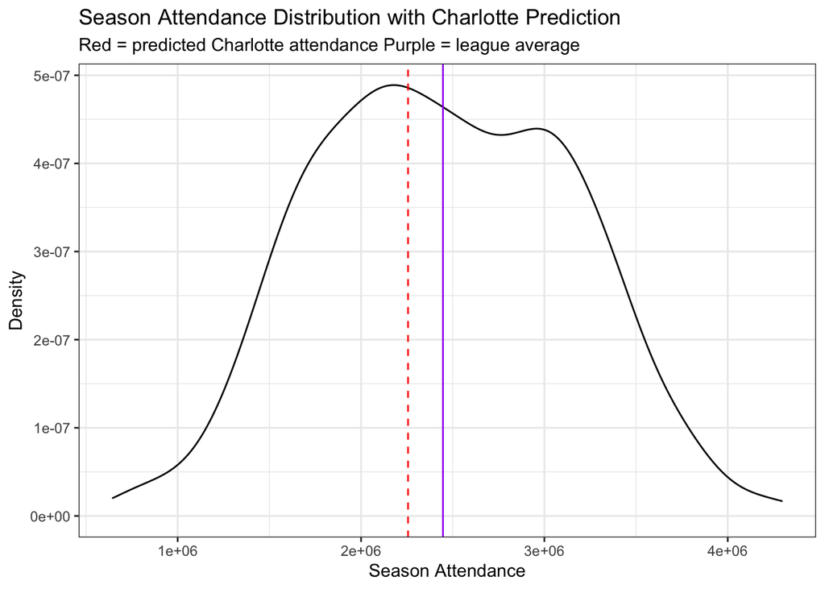

```r
ggplot(teams, aes(x = attendance)) +
  geom_density() +
  geom_vline(xintercept = predicted_attendance, color = "red", linetype = "dashed") +
  geom_vline(xintercept = mean(teams$attendance), color = "purple", linetype = "solid") +
  labs(
    title = "Season Attendance Distribution with Charlotte Prediction",
    subtitle = "Red = predicted Charlotte attendance Purple = league average",
    x = "Season Attendance",
    y = "Density"
  ) +
  theme_bw()
```

**Data sources:** MLB statistics via the [Lahman R package](http://www.seanlahman.com/baseball-archive/statistics/); population figures via the [U.S. Census Bureau](https://www.census.gov/programs-surveys/popest.html) and Statistics Canada (for Toronto).

# 4 Does Team Performance Move Attendance?

## 4.1 Defining performance tiers

Rather than using win percentage as a raw continuous variable, this section asks a more interpretable question: does being a low, medium, or high performing team produce a meaningfully different attendance outcome? Win percentage across the dataset is roughly normally distributed, so I used that shape to set intuitive, round-number cutoffs.

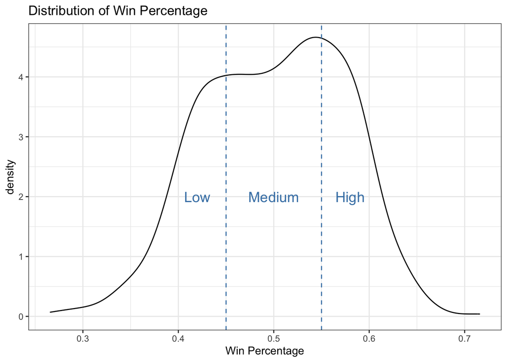

```r
ggplot(teams, aes(x = win_pct)) +
  geom_density() +
  theme_bw() +
  geom_vline(xintercept = .45, color = "steelblue", linetype = "dashed") +
  geom_vline(xintercept = .55, color = "steelblue", linetype = "dashed") +
  labs(title = "Distribution of Win Percentage", x = "Win Percentage") +
  annotate("text", x = .42, y = 2, label = "Low", color = "steelblue", size = 5) +
  annotate("text", x = .50, y = 2, label = "Medium", color = "steelblue", size = 5) +
  annotate("text", x = .58, y = 2, label = "High", color = "steelblue", size = 5)
```

Based on that distribution, I defined low performance as a win percentage at or below .45, medium as between .45 and .55, and high as above .55.

```r
teams <- teams %>%
  mutate(performance = case_when(
    win_pct <= .45 ~ "low",
    win_pct <= .55 ~ "medium",
    win_pct > .55 ~ "high"
  ))
```

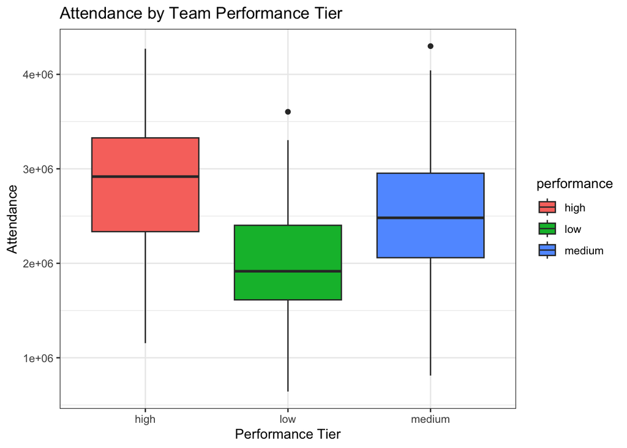

```r
ggplot(teams, aes(x = performance, y = attendance, fill = performance)) +
  geom_boxplot() +
  theme_bw() +
  labs(title = "Attendance by Team Performance Tier", x = "Performance Tier", y = "Attendance")
```

## 4.2 Testing the difference with ANOVA

The boxplot suggests attendance rises with performance tier, but boxplots alone don’t tell us whether that difference is statistically meaningful or just noise. To quantify the difference I will use ANOVA.

```r
anova_result <- aov(attendance ~ performance, data = teams)
summary(anova_result)
```

```
##              Df    Sum Sq   Mean Sq F value Pr(>F)
## performance   2 5.326e+13 2.663e+13   67.56 <2e-16 ***
## Residuals   569 2.243e+14 3.942e+11
## ---
## Signif. codes:  0 '***' 0.001 '**' 0.01 '*' 0.05 '.' 0.1 ' ' 1
```

The ANOVA returns a very small p-value, so I reject the null hypothesis: attendance differs across performance tiers. That justifies swapping the continuous win_pct variable for the categorical performance variable in the attendance model.

```r
attendance_model_tiered <- lm(
  attendance ~ population + MedHouseIncome + teamPayroll + performance + HR + SHO,
  data = teams
)

summary(attendance_model_tiered)
```

```
##
## Call:
## lm(formula = attendance ~ population + MedHouseIncome + teamPayroll +
##     performance + HR + SHO, data = teams)
##
## Residuals:
##      Min       1Q   Median       3Q      Max
## -1374630  -371342   -50384   408402  1401327
##
## Coefficients:
##                     Estimate Std. Error t value Pr(>|t|)
## (Intercept)        2.527e+06  1.842e+05  13.718  < 2e-16 ***
## population         2.051e-02  5.380e-03   3.812 0.000153 ***
## MedHouseIncome    -4.676e+00  1.579e+00  -2.962 0.003188 **
## teamPayroll        7.675e-03  5.964e-04  12.869  < 2e-16 ***
## performancelow    -6.312e+05  7.541e+04  -8.371 4.54e-16 ***
## performancemedium -2.790e+05  5.718e+04  -4.879 1.39e-06 ***
## HR                -1.415e+03  6.917e+02  -2.046 0.041222 *
## SHO               -1.383e+04  6.767e+03  -2.044 0.041422 *
## ---
## Signif. codes:  0 '***' 0.001 '**' 0.01 '*' 0.05 '.' 0.1 ' ' 1
##
## Residual standard error: 512800 on 564 degrees of freedom
## Multiple R-squared:  0.4656, Adjusted R-squared:  0.459
## F-statistic: 70.21 on 7 and 564 DF,  p-value: < 2.2e-16
```

## 4.3 Predicting Charlotte’s attendance across performance scenarios

```r
charlotte_low <- data.frame(
  population = 2367000, MedHouseIncome = 84796,
  teamPayroll = mean(teams$teamPayroll), performance = "low",
  HR = mean(teams$HR), SHO = mean(teams$SHO)
)
charlotte_medium <- data.frame(
  population = 2367000, MedHouseIncome = 84796,
  teamPayroll = mean(teams$teamPayroll), performance = "medium",
  HR = mean(teams$HR), SHO = mean(teams$SHO)
)
charlotte_high <- data.frame(
  population = 2367000, MedHouseIncome = 84796,
  teamPayroll = mean(teams$teamPayroll), performance = "high",
  HR = mean(teams$HR), SHO = mean(teams$SHO)
)

predicted_low <- predict(attendance_model_tiered, newdata = charlotte_low)
predicted_medium <- predict(attendance_model_tiered, newdata = charlotte_medium)
predicted_high <- predict(attendance_model_tiered, newdata = charlotte_high)

predicted_low
```

```
##       1
## 1903882
```

```r
predicted_medium
```

```
##       1
## 2256104
```

```r
predicted_high
```

```
##       1
## 2535080
```

The tiered model predicts roughly 1,903,000 fans for a low performing Charlotte team, 2,256,000 for a medium performing team, and 2,535,000 for a high performing team.

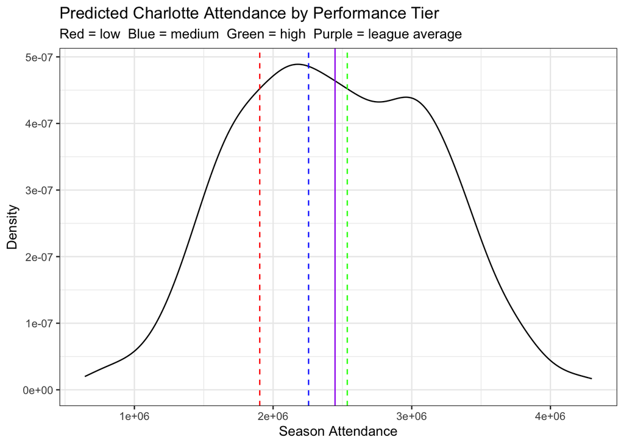

```r
ggplot(teams, aes(x = attendance)) +
  geom_density() +
  geom_vline(xintercept = predicted_low, color = "red", linetype = "dashed") +
  geom_vline(xintercept = predicted_medium, color = "blue", linetype = "dashed") +
  geom_vline(xintercept = predicted_high, color = "green", linetype = "dashed") +
  geom_vline(xintercept = mean(teams$attendance), color = "purple", linetype = "solid") +
  labs(
    title = "Predicted Charlotte Attendance by Performance Tier",
    subtitle = "Red = low  Blue = medium  Green = high  Purple = league average",
    x = "Season Attendance",
    y = "Density"
  ) +
  theme_bw()
```

# 5. What Should Tickets Cost?

## 5.1 A simple market-size model

Ticket pricing was modeled as a function of metropolitan population, under the reasoning that larger markets can typically support higher prices because of greater ticket demand relative to stadium capacity. This model is intentionally the simplest one in the analysis, using only 10 franchises for which comparable price data was publicly available.

```r
ticket_data <- data.frame(
  franchID = c("NYA", "HOU", "CHN", "LAN", "WSN", "PIT", "CHA", "CIN", "ARI", "FLA"),
  population = c(19940274, 7796182, 9408576, 12927614, 6430489,
                 2429469, 9408576, 2282624, 5186958, 6457988),
  ticket_price = c(67.75, 64.29, 55.10, 54.24, 46.02,
                    26.93, 25.58, 25.58, 25.15, 23.61)
)

ticket_model <- lm(ticket_price ~ population, data = ticket_data)
summary(ticket_model)
```

```
##
## Call:
## lm(formula = ticket_price ~ population, data = ticket_data)
##
## Residuals:
##      Min       1Q   Median       3Q      Max
## -18.7518  -7.2200  -0.7287   7.0733  23.9244
##
## Coefficients:
##              Estimate Std. Error t value Pr(>|t|)
## (Intercept) 2.119e+01  8.061e+00   2.628   0.0303 *
## population  2.460e-06  8.388e-07   2.933   0.0189 *
## ---
## Signif. codes:  0 '***' 0.001 '**' 0.01 '*' 0.05 '.' 0.1 ' ' 1
##
## Residual standard error: 13.18 on 8 degrees of freedom
## Multiple R-squared:  0.5181, Adjusted R-squared:  0.4578
## F-statistic:   8.6 on 1 and 8 DF,  p-value: 0.01892
```

## 5.2 Predicting a Charlotte ticket price

```r
charlotte_ticket_data <- data.frame(population = 2805115)  # 2023 Census estimate
predicted_price <- predict(ticket_model, newdata = charlotte_ticket_data)

cat("Recommended average ticket price per game for a Charlotte MLB team: $",
    round(predicted_price, 2), "\n", sep = "")
```

```
## Recommended average ticket price per game for a Charlotte MLB team: $28.09
```

Charlotte sits in a similar population range to Pittsburgh and Cincinnati in this sample, and the predicted price is consistent with those markets, and reasonably close to MLB’s average ticket price of roughly $38. In practice, this figure should be treated as a starting point that a front office would adjust for stadium design, local cost of living, and the competitive presence of the nearby Atlanta Braves.

**Data sources:** Ticket prices from [DrRoto.com](https://drroto.com/blog/26719/mlb-most-and-least-expensive-tickets-to-attend-a-game/), 2025 MLB average ticket prices for the sampled teams; population data from the U.S. Census Bureau and Statistics Canada. A complete list of team-by-team ticket prices was not freely available, so this model was built from the top- and bottom-priced teams in the public sample. A more comprehensive version would incorporate Team Marketing Report’s Fan Cost Index, which is a paid data source.

# 6. Where Does MLB Revenue Come From?

According to Sportico Research, MLB team revenue breaks down roughly as follows: 31% from ticket/seating sales, 26% from national and shared revenue, 23% from local media rights, 11% from team sponsorships, and 10% from concessions and parking. This breakdown is used in the next section to back into a full revenue estimate from the ticket revenue figure alone.

# 7. Estimating Charlotte’s Total Revenue and Payroll Capacity

Assuming medium performance, the tiered model projects roughly 2,256,000 visitors across a season. At the predicted ticket price of $28.09, that implies approximately $63.4 million in ticket revenue. MLB teams pay 48% of local ticket revenue into a national pool, and in turn receive back roughly 118 million in ticket revenue shares plus 91 million from other national funds. Net of Charlotte’s contribution to the pool (about $30.4 million), that puts combined ticket and national-fund revenue at roughly 242 million.

Since ticket sales and national revenue together account for only about 57% of a typical MLB team’s total revenue (per the Sportico breakdown), dividing by 0.57 extrapolates a total franchise revenue of approximately 424 million. This figure lines up reasonably well with revenue reported for comparable MLB franchises.

Other MLB teams spend anywhere from 27% to 90% of total revenue on payroll. Applied to Charlotte’s estimated revenue, that implies a payroll range of roughly 115 million to 382 million while remaining profitable by the standards of existing franchises which is a workable and competitive range for a new team.

**Sources:** [Twins Trivia — MLB Revenue vs. Payroll](https://twinstrivia.com/2025/04/05/mlb-teams-revenue-versus-payroll/); [Bless You Boys — MLB’s Revenue Sharing Problem](https://www.blessyouboys.com/2021/12/16/22831008/mlbs-revenue-sharing-problem-and-how-to-solve-it)

# 8. Limitations and Next Steps

This analysis posits that Charlotte would be a viable host city for a new MLB team. However, the analysis is limited by a small number of variables and observations. The attendance model only explains about half of the yearly variation in attendance, so factors it doesn’t capture like stadium size, ticket promotions, weather, and local economic conditions in a given year likely matter just as much as the variables included here. The ticket price model is especially limited, since it was built from only 10 teams rather than the full league, which makes the predicted price a rough estimate rather than a precise number. The revenue and payroll figures in Section 7 are even further removed from hard data, since they were built by chaining several assumptions together (ticket price, revenue-sharing rates, and industry-wide revenue breakdowns), so small errors early in that chain could meaningfully shift the final numbers. Finally, this analysis doesn’t account for costs and risks that any actual expansion decision would involve, such as an MLB expansion fee, stadium construction costs, ownership financing, or how much a Charlotte team’s attendance might be affected by nearby competition from the Atlanta Braves. A more complete study would incorporate these factors along with a larger, more consistent set of ticket pricing data.